# CMSC320_Final_Project

## Predicting the Valence of Pop Songs through Spotify's Audio Features

### CMSC320 Data Science Final Tutorial

**Tutorial by Dylan Nguyen**

[figure not shown]

[Image from Spotify](https://newsroom.spotify.com/2020-03-25/how-spotify-is-addressing-covid-19-on-platform-and-off/)

## Motivation

Music is great! And Spotify is one of the most popular music streaming platforms in the United States. I can attest to that by saying I am one of its daily users.  
While I was brainstorming ideas for a potential final project, music was at the top of my list of interests. I looked especially for any dataset related to Spotify. One of my favorite music genres is pop music! When I listen to pop music, I am generally trying to get into a good mood or am in a good mood. As I explored what types of data was available, I found a dataset with an audio feature called Valence which caught my attention. Valence is the measure of musical postiveness conveyed by a song. Or in other words, the measure of happiness in a song! Pop music plays a large role in my life in cheering me up or enjoying time with friends, so exploring a pop song's valence is compelling to me. This is why I wanted to research more into it and hopefully figure out if there is some relationship or outcome I can find with the Valence of a song.

## Gathering Data

I explored different datasets available on [Kaggle](https://www.kaggle.com/). I really liked how Kaggle provides free, easy to use, and organized data so gathering data is easier! There were a lot of Spotify related datasets, but I settled with the one with the most data (about 2000 songs available) and interesting attributes to look at. This dataset represents the top 2000 songs on spotify. This dataset contains audio statistics of the top 2000 tracks on Spotify. Each column had a unique audio feature rating for songs. Some interesting column names that I found interesting were Valence, Danceability, and Energy. There is also a Popularity column that will also be put into the same grouping as Audio Feature. It is not necessary an attribute that contributes the song's audio, but will be interesting to look at. It is important to note there are a lot of genres in this dataset, so creating a subset for pop songs will be necessary and explained in a later section.  
The dataframe contained the following content:

- Index: ID
- Title: Name of the Track
- Artist: Name of the Artist
- Top Genre: Genre of the track
- Year: Release Year of the track
- Beats per Minute(BPM): The tempo of the song
- Energy: The energy of a song - the higher the value, the more energtic. song
- Danceability: The higher the value, the easier it is to dance to this song.
- Loudness: The higher the value, the louder the song.
- Valence: The higher the value, the more positive mood for the song.
- Length: The duration of the song.
- Acoustic: The higher the value, the more acoustic the song is.
- Speechiness: The higher the value, the more spoken words the song contains
- Popularity: The higher the value, the more popular the song is.

[Kaggle Link to Data Set](https://www.kaggle.com/iamsumat/spotify-top-2000s-mega-dataset)

## Setup: Data Curation and Management

Make sure to download and use the packages shown below for this tutorial. There are links at the very end of the tutorial page if you need to access the resources directly. This tutorial will assume you have Python3 installed.

```python
# Imports that will be required for this tutorial
import pandas as pd
from pandas.plotting import scatter_matrix
import numpy as np
import matplotlib.pyplot as plt
import seaborn as sns

# Packages used in the Machine Learning portion
from sklearn import model_selection
from sklearn import linear_model
from statsmodels import api
from scipy.stats import pearsonr
```

### Loading the Data

After downloading the file from Kaggle, make sure to put the csv file into the same directory as your Python file. We will utilize Pandas' read_csv() function to put all the data into a dataframe variable nicely and quickly for us.  
If everything works out, you should see a similar output as below after returning the head of the data frame.

```python
data = pd.read_csv("Spotify-top-2000.csv")
data.head()
```

|  | Index | Title | Artist | Top Genre | Year | Beats Per Minute (BPM) | Energy | Danceability | Loudness (dB) | Liveness | Valence | Length (Duration) | Acousticness | Speechiness | Popularity |
| --- | --- | --- | --- | --- | --- | --- | --- | --- | --- | --- | --- | --- | --- | --- | --- |
| 0 | 1 | Sunrise | Norah Jones | adult standards | 2004 | 157 | 30 | 53 | -14 | 11 | 68 | 201 | 94 | 3 | 71 |
| 1 | 2 | Black Night | Deep Purple | album rock | 2000 | 135 | 79 | 50 | -11 | 17 | 81 | 207 | 17 | 7 | 39 |
| 2 | 3 | Clint Eastwood | Gorillaz | alternative hip hop | 2001 | 168 | 69 | 66 | -9 | 7 | 52 | 341 | 2 | 17 | 69 |
| 3 | 4 | The Pretender | Foo Fighters | alternative metal | 2007 | 173 | 96 | 43 | -4 | 3 | 37 | 269 | 0 | 4 | 76 |
| 4 | 5 | Waitin' On A Sunny Day | Bruce Springsteen | classic rock | 2002 | 106 | 82 | 58 | -5 | 10 | 87 | 256 | 1 | 3 | 59 |

### Data Tidying

We can see that there is an index column that won't be necesary for this tutorial. If we ever need to access the index, the dataframe will already have the index saved through the way Pandas sets up the dataframe. We will also use the .dropna() function to remove any null data in case there are any (This will also help if the dataset gets updated and ends up having a null value somehow).

```python
# Uses the drop function from Pandas to remove the column.
data = data.drop(columns ='Index',axis=1)
```

Now our data still contains all the different genres of songs. So we will now do some magic (regular expression) to only capture any songs with 'pop' in the string of the genre. This will capture all the Pop related songs and I checked everything listed in the 'Top Genre' column to make sure I did not miss any genres related to pop.  
If you are unfamiliar with Regular Expression, there is a link at the end of the tutorial for more information. But just note that we won't dive any deeper into regular expression after the code below.

```python
# This will create a new data frame for any songs with pop genre relations.
# Regular expression is used here to search any 'pop' string.
pop_songs = data[data['Top Genre'].str.contains(r'pop')]
pop_songs.head()
```

|  | Title | Artist | Top Genre | Year | Beats Per Minute (BPM) | Energy | Danceability | Loudness (dB) | Liveness | Valence | Length (Duration) | Acousticness | Speechiness | Popularity |
| --- | --- | --- | --- | --- | --- | --- | --- | --- | --- | --- | --- | --- | --- | --- |
| 5 | The Road Ahead (Miles Of The Unknown) | City To City | alternative pop rock | 2004 | 99 | 46 | 54 | -9 | 14 | 14 | 247 | 0 | 2 | 45 |
| 6 | She Will Be Loved | Maroon 5 | pop | 2002 | 102 | 71 | 71 | -6 | 13 | 54 | 257 | 6 | 3 | 74 |
| 18 | Music | John Miles | classic uk pop | 2004 | 87 | 31 | 27 | -13 | 63 | 12 | 352 | 1 | 3 | 46 |
| 19 | Cry Me a River | Justin Timberlake | dance pop | 2002 | 74 | 65 | 62 | -7 | 10 | 56 | 288 | 57 | 18 | 74 |
| 22 | Als De Morgen Is Gekomen | Jan Smit | dutch pop | 2006 | 96 | 89 | 63 | -6 | 9 | 81 | 176 | 5 | 3 | 55 |

Here we can see that there are integer values for each value in the different audio feature columns. It is in our favor to convert them into floats because it'll help in the machine learning section later. The outputs you see below will allow you to see what data types the columns are and the overall changes.

```python
# These are the column names that contains values that should be edited.
to_be_edited_cols = ['Beats Per Minute (BPM)', 'Energy', 'Danceability', 'Loudness (dB)', 'Liveness',
                     'Valence', 'Length (Duration)', 'Acousticness', 'Speechiness', 'Popularity']

# For loop that will iterate through the list and edit the columns in the dataframe accordingly
for aud_feat in to_be_edited_cols:
    pop_songs = pop_songs.astype({aud_feat: float})

print(pop_songs.dtypes)
pop_songs.head()
```

[output not shown]

[output not shown]

### Missing Data?

Let's run some code to see if there are any missing data in any parts of the datarame.

```python
pop_songs.isnull().values.any()
```

```
False
```

This nifty statement tells us that there is no missing/null data in our data frame. This is great and lets us continue onto the next steps without worrying about it.  
NOTE: if for some reason the statement returns true, run the following code to make sure we do not have any null values. For testing purposes, I used the danceability column but you may replace the string literal with any column name you want to fix.

```python
column_name = "Danceability"  # Replace the string literal here if needed.
pop_songs = pop_songs[pd.notnull(pop_songs[column_name])]
```

### Additional Adjustments

It will be nice to see the Valence column towards the left side of the dataframe to make it easier to glance at the valence values. So let's readjust the columns.  
Here we also sort the values by popularity just to see the songs in some ordering for now while being able to see our updates. Now take a look at our updated dataframe!

```python
print(list(data.columns.values))
pop_songs = pop_songs[['Title', 'Artist', 'Top Genre', 'Year', 'Valence', 'Beats Per Minute (BPM)', 'Energy', 'Danceability', 'Loudness (dB)', 'Liveness', 'Length (Duration)', 'Acousticness', 'Speechiness', 'Popularity']]
pop_songs = pop_songs.sort_values(by=['Popularity'], ascending=False)
pop_songs.head()
```

```
['Title', 'Artist', 'Top Genre', 'Year', 'Beats Per Minute (BPM)', 'Energy', 'Danceability', 'Loudness (dB)', 'Liveness', 'Valence', 'Length (Duration)', 'Acousticness', 'Speechiness', 'Popularity']
```

|  | Title | Artist | Top Genre | Year | Valence | Beats Per Minute (BPM) | Energy | Danceability | Loudness (dB) | Liveness | Length (Duration) | Acousticness | Speechiness | Popularity |
| --- | --- | --- | --- | --- | --- | --- | --- | --- | --- | --- | --- | --- | --- | --- |
| 793 | Dance Monkey | Tones and I | australian pop | 2019 | 51.0 | 98.0 | 59.0 | 82.0 | -6.0 | 15.0 | 209.0 | 69.0 | 9.0 | 100.0 |
| 787 | Memories | Maroon 5 | pop | 2019 | 57.0 | 91.0 | 32.0 | 76.0 | -7.0 | 8.0 | 189.0 | 84.0 | 5.0 | 98.0 |
| 786 | bad guy | Billie Eilish | electropop | 2019 | 56.0 | 135.0 | 43.0 | 70.0 | -11.0 | 10.0 | 194.0 | 33.0 | 38.0 | 95.0 |
| 1641 | All I Want for Christmas Is You | Mariah Carey | dance pop | 1994 | 35.0 | 150.0 | 63.0 | 34.0 | -7.0 | 7.0 | 241.0 | 16.0 | 4.0 | 95.0 |
| 726 | Shallow | Lady Gaga | dance pop | 2018 | 32.0 | 96.0 | 39.0 | 57.0 | -6.0 | 23.0 | 216.0 | 37.0 | 3.0 | 88.0 |

## Data Exploration: Visualization and Analysis

### Quick Genre & Sub-genre Analysis

Let's see how many genres we are able to narrow down from the original 2000 songs dataframe.

```python
print("Number of genres/sub-genres in original data frame:",len(data['Top Genre'].unique()))  # Shows total amount of genres and sub-genres.
print("Number of genres/sub-genres in pop_songs data frame:",len(pop_songs['Top Genre'].unique()))  #  Shows total amount of pop genres and sub-genres.
```

```
Number of genres/sub-genres in original data frame: 149
Number of genres/sub-genres in pop_songs data frame: 41
```

From the code above, we can see that we are able to narrow down 41 pop genre and sub-genres from the original 149! 149 is a crazy amount and it is surprising to see how many different types of music there are in Spotify's top 2000 songs. Metropopolis was one of the sub-genres I found interesting.  
It is interesting to take a quick look at all the genres/sub-genres, but there is a lot to be outputted. If you really want to take a peek at all the different genres/sub-genres, run the code below:

Note: This only prints the first 10 genres available so if you want to see more, remove the [ ] braces used for Python list splicing.

```python
print(data['Top Genre'].unique()[0:10])  # Shows that there a variety of genres and sub-genres.
print(pop_songs['Top Genre'].unique()[0:10])  # Shows that there a variety of pop genres and sub-genres.
```

```
['adult standards' 'album rock' 'alternative hip hop' 'alternative metal'
 'classic rock' 'alternative pop rock' 'pop' 'modern rock'
 'detroit hip hop' 'alternative rock']
['australian pop' 'pop' 'electropop' 'dance pop' 'baroque pop' 'indie pop'
 'canadian pop' 'acoustic pop' 'folk-pop' 'danish pop']
```

### More Dataframe Analysis

Now let's look at how many songs are in our pop song dataframe and how many unique artists there are.

```python
print("Number of Pop Songs:",len(pop_songs))  # Prints the amount of pop songs
print("Number of Artists:",len(pop_songs['Artist'].unique()))  # Prints the amount of unique artists
```

```
Number of Pop Songs: 398
Number of Artists: 188
```

Since there is a lower amount of artists compared to the amount of songs available in our dataframe, we can tell that there are some artist that had more than one song in the data frame. We can look at who are some of the top pop artists in Spotify by counting up the number of times an artist appears in our dataframe.

```python
# Code that stores the top artists in a data frame by order of total songs found
top_artists = pop_songs['Artist'].value_counts().to_frame().reset_index()
top_artists.columns = ['Artist','Total Songs']  # Fixes columns
top_artists.head(30)
```

|  | Artist | Total Songs |
| --- | --- | --- |
| 0 | Michael Jackson | 23 |
| 1 | ABBA | 22 |
| 2 | BLØF | 17 |
| 3 | Ed Sheeran | 12 |
| 4 | Andre Hazes | 11 |
| 5 | Kensington | 10 |
| 6 | Guus Meeuwis | 9 |
| 7 | P!nk | 7 |
| 8 | Robbie Williams | 7 |
| 9 | Beyoncé | 7 |
| 10 | Herman van Veen | 5 |
| 11 | The Beach Boys | 5 |
| 12 | The Cats | 5 |
| 13 | Whitney Houston | 5 |
| 14 | Madonna | 5 |
| 15 | Bruno Mars | 4 |
| 16 | Crowded House | 4 |
| 17 | Rob De Nijs | 4 |
| 18 | Lady Gaga | 4 |
| 19 | The War On Drugs | 4 |
| 20 | Stromae | 4 |
| 21 | Elbow | 4 |
| 22 | Oasis | 4 |
| 23 | Dolly Parton | 4 |
| 24 | Kate Bush | 4 |
| 25 | Mark Ronson | 3 |
| 26 | Justin Timberlake | 3 |
| 27 | Donna Summer | 3 |
| 28 | Rihanna | 3 |
| 29 | Herbert Grönemeyer | 3 |

The dataframe allows to us to see which Pop artists made the most hits in the Spotify Top 2000 chart from our original data frame. I recognize Michael Jackson, Ed Sheeran, P!nk, Beyoncé and Bruno Mars, mainly because they are popular in the United States. Do you recognize anyone?  
Let's just run an intial plot for this to put things into perspective. It should be pretty hard to see who is who, but will let us get a nice overall picture of how many artists have multiple songs in the overall dataframe.

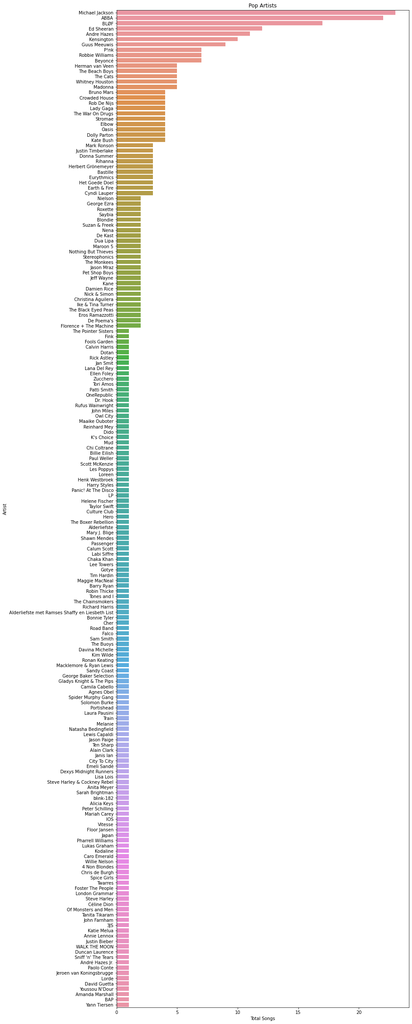

```python
# Code that creates the bar graph
plt.figure(figsize=(12,42))
sns.barplot(data=top_artists, y='Artist', x='Total Songs')
plt.title("Pop Artists")
plt.xlabel("Total Songs")
plt.show()
```

As expected, the graph is very long and stretched out. You cannot even read the artist names nor the values on the y axis. So let's tune it down and just look at the top of the barrel.  
Let's look at the top 15 pop artists visually in a simpler bar graph instead.

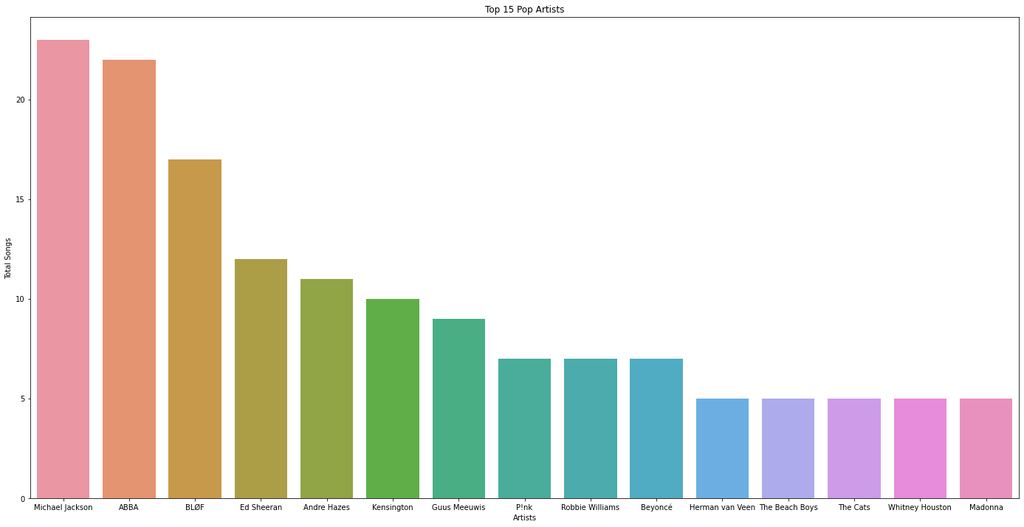

```python
# Code that creates the bar graph
plt.figure(figsize=(24,12))
sns.barplot(data=top_artists.head(15), x='Artist', y='Total Songs')
plt.title("Top 15 Pop Artists")
plt.xlabel("Artists")
plt.show()
```

It is not surprising to see the King of Pop (Michael Jackson) leading in popularity in pop songs. It is also nice to see a lot of artists not as well known in the United States shown on this bar graph. This could let American pop genre fans explore international music outside of just the usual American pop they may be used to, or vice versa with fans around the world exploring American pop! I, myself looked up who ABBA and BLØF were. Both are European bands!